# eBird Analysis — Bludenz, Suchardstraße 5

- Show All Code
- Hide All Code
- View Source

Patch checklist data, December 2016 – October 2025

Author

Posit Assistant

Published

August 17, 2026

## Overview

This report analyses a personal eBird “My eBird Data” export for a single location — **Bludenz, Suchardstraße 5** (47.16 °N, 9.82 °E), Vorarlberg, Austria. The data are garden/patch checklists spanning December 2016 to October 2025.

The eBird taxonomy from the [`auk`](https://cornelllabofornithology.github.io/auk/) package is used to attach family and order to every species.

```r
library(readxl)
library(dplyr)
library(tidyr)
library(lubridate)
library(stringr)
library(forcats)
library(ggplot2)
library(scales)
library(auk)

theme_set(theme_minimal(base_size = 12))

path <- "BludenzSuchardstr5_bisOkt19_2025-corrected.xlsx"
```

## Load and clean

The raw export needs three fixes: the latitude/longitude are stored as integers scaled by 10<sup>7</sup>, the `Time` column carries a spurious 1899 date, and useful temporal fields (year, month, hour) are derived for the analysis.

```r
raw <- read_excel(path, sheet = "bisOkt19_2025")

birds <- raw |>
  mutate(
    latitude     = Latitude / 1e7,
    longitude    = Longitude / 1e7,
    date         = as_date(Date),
    year         = year(date),
    month        = month(date, label = TRUE),
    hour         = hour(Time),
    duration_min = `Duration (Min)`,
    count_num    = suppressWarnings(as.numeric(Count))
  )

# Attach family / order from the auk eBird taxonomy
tax <- ebird_taxonomy |>
  select(scientific_name, family, order)

birds <- birds |>
  left_join(tax, by = c("Scientific Name" = "scientific_name"))
```

```r
tibble(
  Metric = c("Observations", "Checklists", "Species", "Families",
             "Orders", "First date", "Last date"),
  Value = c(
    format(nrow(birds), big.mark = ","),
    format(n_distinct(birds$`Submission ID`), big.mark = ","),
    as.character(n_distinct(birds$`Common Name`)),
    as.character(n_distinct(birds$family)),
    as.character(n_distinct(birds$order)),
    as.character(min(birds$date)),
    as.character(max(birds$date))
  )
) |>
  knitr::kable()
```

| Metric | Value |
| --- | --- |
| Observations | 6,324 |
| Checklists | 810 |
| Species | 78 |
| Families | 25 |
| Orders | 9 |
| First date | 2016-12-27 |
| Last date | 2025-10-19 |

## Sampling effort

Effort at a patch shapes everything else, so we look at it first. Checklists are unevenly distributed across the study period, ramping up sharply from 2020 onward.

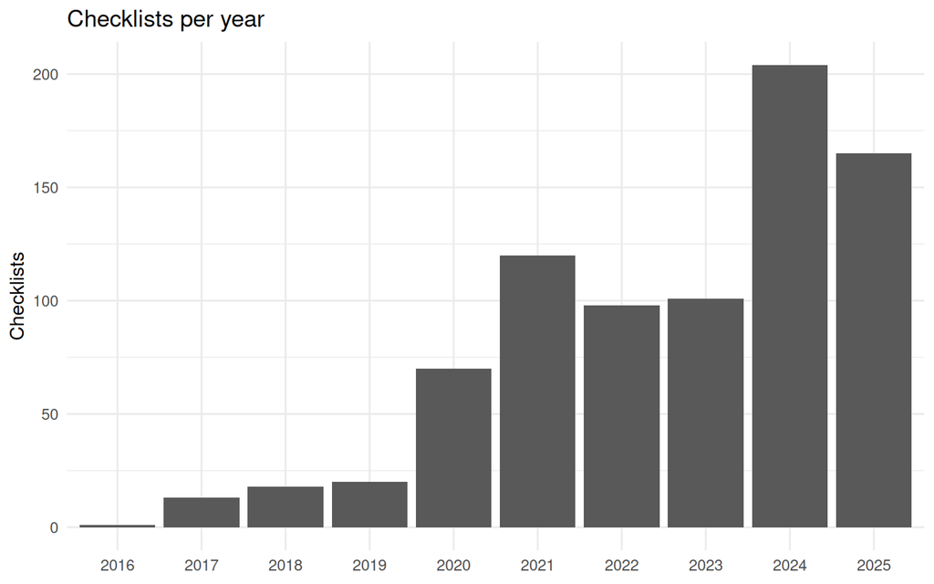

```r
birds |>
  distinct(`Submission ID`, year) |>
  count(year) |>
  ggplot(aes(factor(year), n)) +
  geom_col() +
  labs(title = "Checklists per year", x = NULL, y = "Checklists")
```

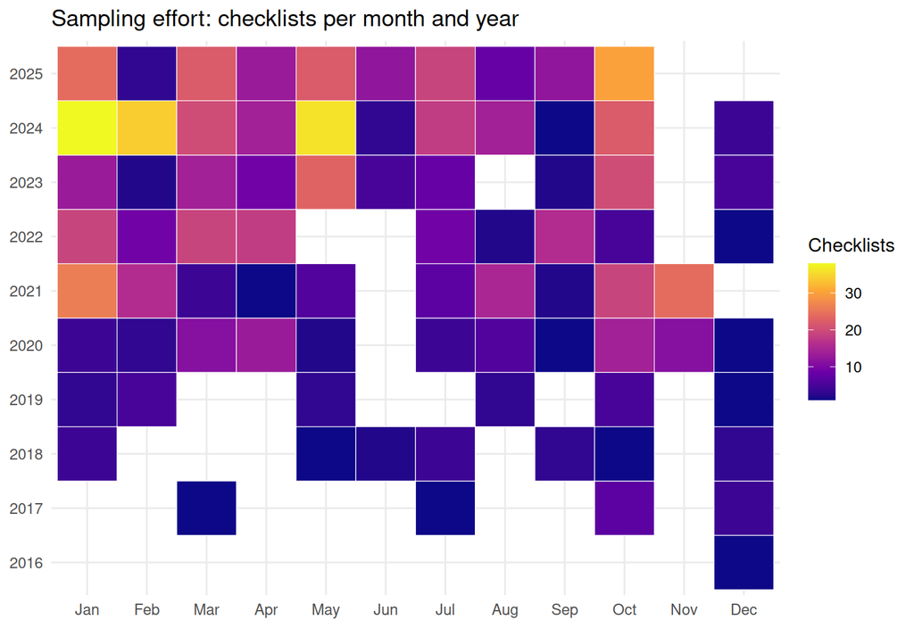

```r
effort <- birds |>
  distinct(`Submission ID`, year, month) |>
  count(year, month)

ggplot(effort, aes(month, factor(year), fill = n)) +
  geom_tile(color = "white") +
  scale_fill_viridis_c(option = "C", name = "Checklists") +
  labs(title = "Sampling effort: checklists per month and year",
       x = NULL, y = NULL)
```

The heatmap shows the recording history is far from balanced — some months in early years have no checklists at all, so between-year comparisons should be read with effort in mind.

## Checklist-level distributions

```r
checklists <- birds |>
  group_by(`Submission ID`) |>
  summarise(
    date = first(date), year = first(year), month = first(month),
    hour = first(hour), duration_min = first(duration_min),
    protocol = first(Protocol), n_species = n_distinct(`Common Name`),
    .groups = "drop"
  )
```

### Duration

Most checklists are short stationary counts; durations above ~4 hours are rare and truncated here for readability.

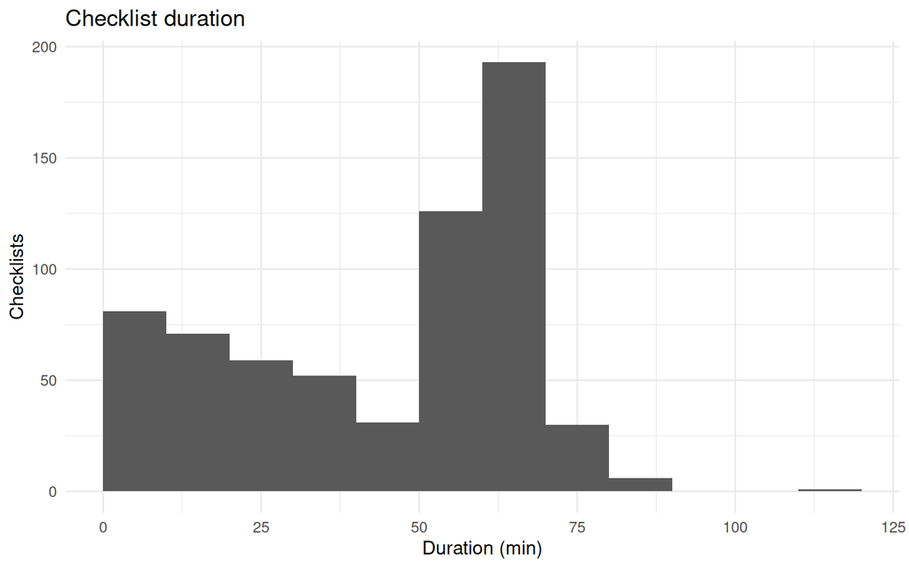

```r
checklists |>
  filter(!is.na(duration_min), duration_min <= 240) |>
  ggplot(aes(duration_min)) +
  geom_histogram(binwidth = 10, boundary = 0) +
  labs(title = "Checklist duration", x = "Duration (min)", y = "Checklists")
```

### Start hour

Recording concentrates in the morning, peaking around 08:00–10:00.

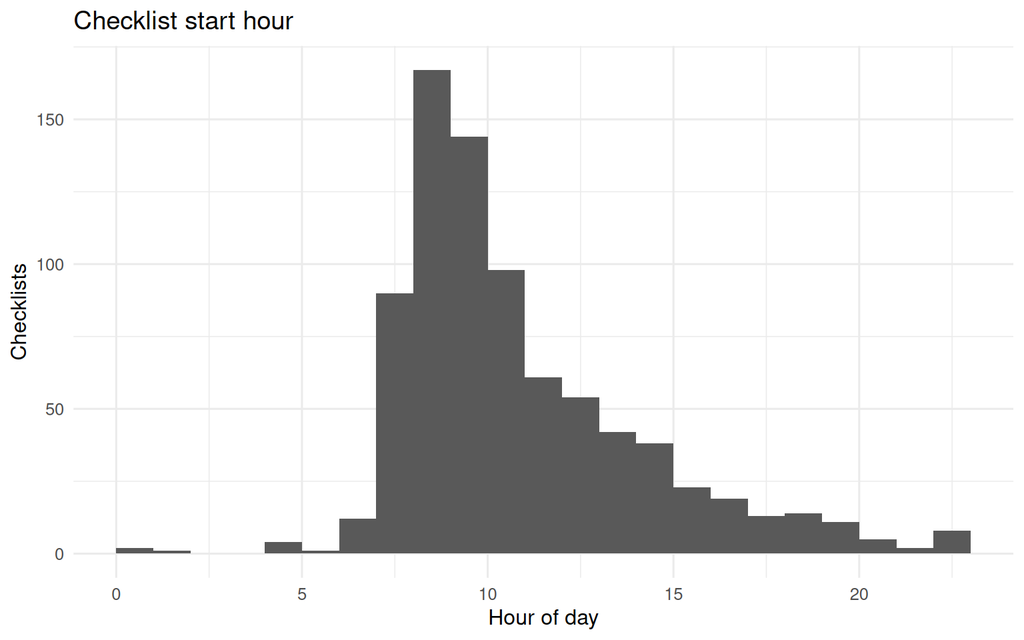

```r
checklists |>
  filter(!is.na(hour)) |>
  ggplot(aes(hour)) +
  geom_histogram(binwidth = 1, boundary = 0) +
  labs(title = "Checklist start hour", x = "Hour of day", y = "Checklists")
```

### Species richness per checklist

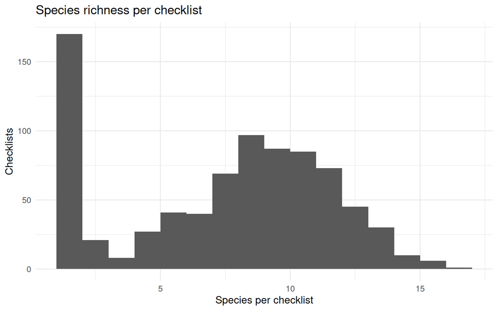

```r
ggplot(checklists, aes(n_species)) +
  geom_histogram(binwidth = 1, boundary = 0) +
  labs(title = "Species richness per checklist",
       x = "Species per checklist", y = "Checklists")
```

## Species composition

Detection frequency is expressed as the share of checklists in which a species was recorded — a more effort-robust measure than raw counts.

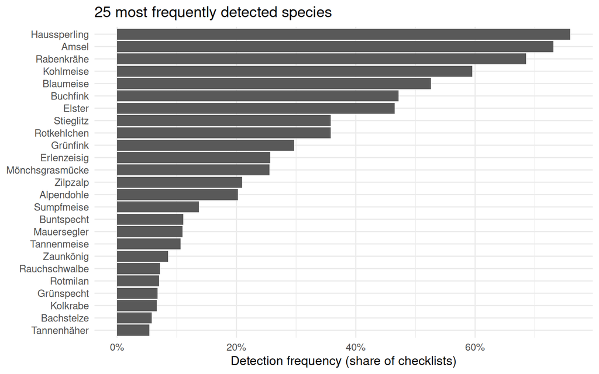

```r
n_cl <- n_distinct(birds$`Submission ID`)

sp_freq <- birds |>
  distinct(`Submission ID`, `Common Name`) |>
  count(`Common Name`, name = "checklists") |>
  mutate(freq = checklists / n_cl) |>
  arrange(desc(checklists))

sp_freq |>
  slice_head(n = 25) |>
  mutate(`Common Name` = fct_reorder(`Common Name`, freq)) |>
  ggplot(aes(freq, `Common Name`)) +
  geom_col() +
  scale_x_continuous(labels = percent) +
  labs(title = "25 most frequently detected species",
       x = "Detection frequency (share of checklists)", y = NULL)
```

### Species per family

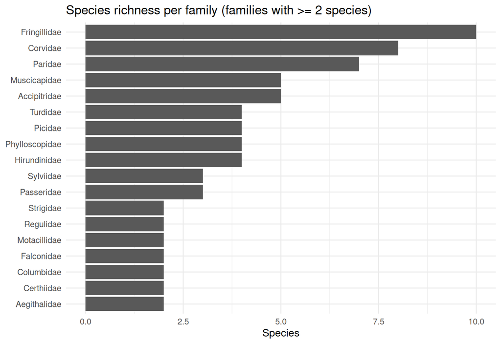

```r
birds |>
  distinct(`Common Name`, family) |>
  count(family, name = "species") |>
  filter(species >= 2) |>
  mutate(family = fct_reorder(family, species)) |>
  ggplot(aes(species, family)) +
  geom_col() +
  labs(title = "Species richness per family (families with >= 2 species)",
       x = "Species", y = NULL)
```

## Seasonality

The seasonal heatmap of the 20 most frequent species divides residents (present year-round) from summer visitors that arrive on migration.

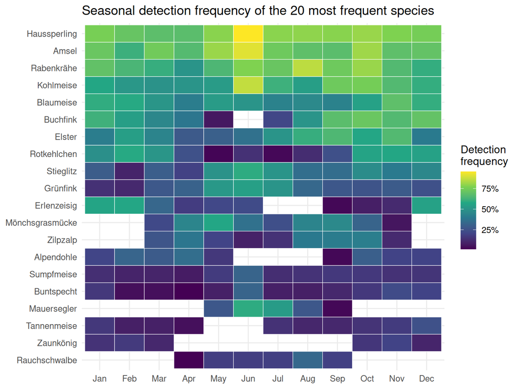

```r
top20 <- sp_freq |> slice_head(n = 20) |> pull(`Common Name`)

n_cl_month <- birds |>
  distinct(`Submission ID`, month) |>
  count(month, name = "n_cl")

season <- birds |>
  filter(`Common Name` %in% top20) |>
  distinct(`Submission ID`, `Common Name`, month) |>
  count(`Common Name`, month, name = "detections") |>
  left_join(n_cl_month, by = "month") |>
  mutate(
    freq = detections / n_cl,
    `Common Name` = factor(`Common Name`, levels = rev(top20))
  )

ggplot(season, aes(month, `Common Name`, fill = freq)) +
  geom_tile(color = "white") +
  scale_fill_viridis_c(option = "D", name = "Detection\nfrequency",
                       labels = percent) +
  labs(title = "Seasonal detection frequency of the 20 most frequent species",
       x = NULL, y = NULL)
```

Species such as *Mönchsgrasmücke* (Blackcap), *Zilpzalp* (Chiffchaff), *Mauersegler* (Common Swift) and *Rauchschwalbe* (Barn Swallow) are effectively absent in winter and peak in the breeding season — the classic signature of long-distance migrants — whereas *Haussperling*, *Amsel* and *Kohlmeise* are detected consistently across all months.

## Notes and caveats

- **Effort is uneven** across years and months; interpret trends cautiously.
- Detection frequency depends on both true abundance and detectability.
- Common names are in **German** as exported from eBird; scientific names and the `auk` taxonomy provide the language-neutral link.
- This is a single-location dataset, so results describe one patch and should not be generalised.